# Complete Time Series Code

## DataSet :

### - finance Data set lib 'yfinance' Rest other dataset may found at Google Trends or Kaggle

```python
#!pip install yfinance  #https://pypi.org/project/yfinance/
import yfinance as yf
df = yf.download(tickers='TSLA',start='2019-01-01', end='2019-12-31', progress=False) # AMZN for amazon and similar
df.head()
```

| Date | Open | High | Low | Close | Adj Close | Volume |
| --- | --- | --- | --- | --- | --- | --- |
| 2018-12-31 | 67.557999 | 67.842003 | 65.052002 | 66.559998 | 66.559998 | 31511500 |
| 2019-01-02 | 61.220001 | 63.026001 | 59.759998 | 62.023998 | 62.023998 | 58293000 |
| 2019-01-03 | 61.400002 | 61.880001 | 59.476002 | 60.071999 | 60.071999 | 34826000 |
| 2019-01-04 | 61.200001 | 63.599998 | 60.546001 | 63.537998 | 63.537998 | 36970500 |
| 2019-01-07 | 64.344002 | 67.348000 | 63.549999 | 66.991997 | 66.991997 | 37756000 |

## Handling Missing Values in time series

```python
import pandas as pd
import numpy as np
import seaborn as sns
import matplotlib.pyplot as plt
plt.style.use('fivethirtyeight')

import warnings
warnings.filterwarnings('ignore')


from sklearn.metrics import mean_squared_error

def plot_data(data,title):
    plt.rcParams['figure.figsize']=(17,5)
    plt.plot(data,color='black')
    plt.title(title)
    plt.show()
```

```python
## Reading dataset
data = pd.read_csv('data/Customers_in_a_Shop.csv',header=None)
data.columns = ['Date','Customers']
data['Date'] = pd.to_datetime(data['Date'],format="%Y-%m")
data = data.set_index('Date')
df = data.copy()
data.head()
```

| Date | Customers |
| --- | --- |
| 1949-01-01 | 114.0 |
| 1949-02-01 | 120.0 |
| 1949-03-01 | 134.0 |
| 1949-04-01 | 67.0 |
| 1949-05-01 | 123.0 |

### Handling Missing Values

1. Mean Imputation
2. LOCF (Last Observation Carried Forward)
3. Linear Interpolation
4. Seasonbal Interpolation Method

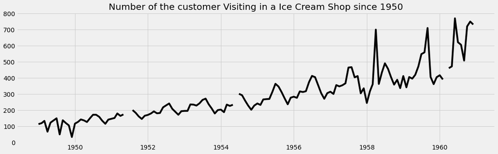

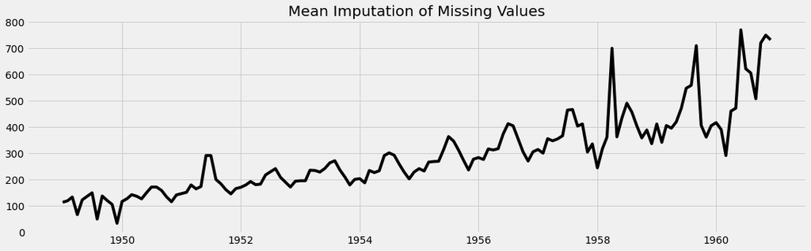

[figure not shown]

[figure not shown]

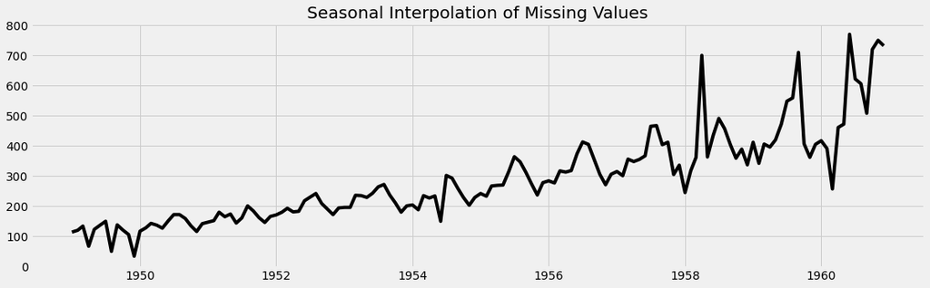

```python
# Checking Missing Values by Visualizing data as we have just 144 datapoints
def plot_data(data,title):
    plt.rcParams['figure.figsize']=(17,5)
    plt.plot(data,color='black')
    plt.title(title)
    plt.show()

# Raw Data
plot_data(data = data, title = "Number of the customer Visiting in a Ice Cream Shop since 1950")

#Mean Imputation
data['Customers_mean'] = data['Customers'].fillna(data['Customers'].mean())
plot_data(data = data['Customers_mean'],title = "Mean Imputation of Missing Values")

# Last Observation Carried forward
data['Customers_mean'] = data['Customers'].bfill()
plot_data(data = data['Customers_mean'],title = "Last Observation Carried Forward")

# Linear Interpolation
data['Customers_linear']=data['Customers'].interpolate(method='linear')
plot_data(data = data['Customers_mean'],title = "Linear Interpolation of Missing Values")

# Seasonal
# print(f"Dates where missing values present : {data.index[data['Customers'].isnull()]}")
data.loc['1960-03'].fillna((data['1949-03':'1959-03':12].sum())/data['1949-03':'1959-03':12].shape[0], inplace=True)
data.loc['1954-06'].fillna((data['1949-06':'1953-06':12].sum())/data['1949-06':'1953-06':12].shape[0], inplace=True)
data.loc['1951-07'].fillna((data['1949-07':'1950-07':12].sum())/data.loc['1949-07':'1950-07':12].shape[0], inplace=True)
data.loc['1951-06'].fillna((data['1949-06':'1950-06':12].sum())/data['1949-06':'1950-06':12].shape[0], inplace=True)
# print(f"Missing Values Count {data.isnull().sum().sum()}")
plot_data(data = data['Customers'],title = "Seasonal Interpolation of Missing Values")
```

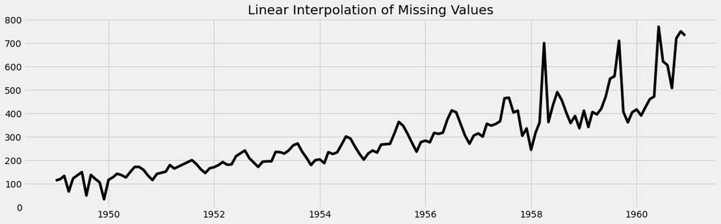

```python
# Filling missing value using Linear interpolation
data = df.copy()
data['Customers_linear']=data['Customers'].interpolate(method='linear')
plot_data(data = data['Customers_linear'],title = "Linear Interpolation of Missing Values")
df = data.copy()
```

## Handling Outliers

### 1. Detection using - Box plot

It is a standardized way of displaying the distribution of data. Any data points which are less than Q1-1.5IQR or greater than Q3+1.5IQR are considered to be outliers.

### 2. Cap - with maximum value

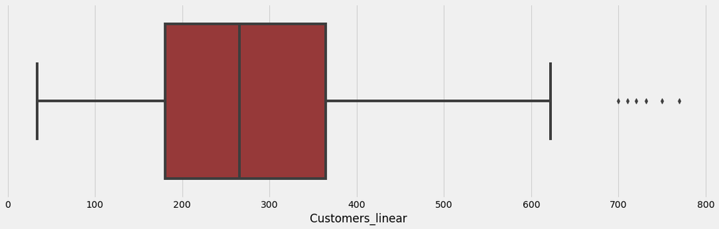

```
Date
1960-06-01    770.0
1960-11-01    750.0
1960-12-01    732.0
1960-10-01    720.0
1959-09-01    710.0
1958-04-01    700.0
1960-07-01    622.0
Name: Customers_linear, dtype: float64
```

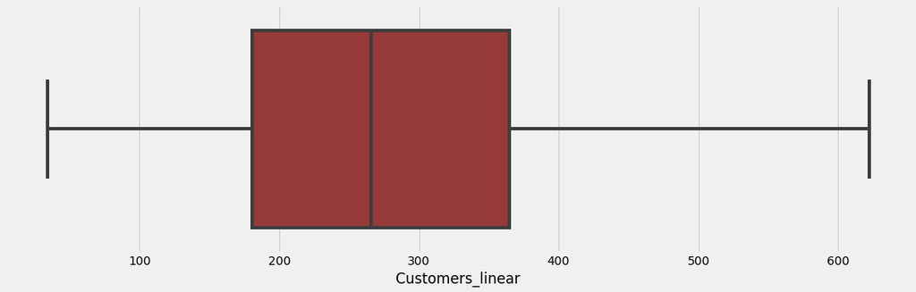

```python
plt.rcParams['figure.figsize']=(17,5)
sns.boxplot(data['Customers_linear'], color='brown')
plt.show()

print(data['Customers_linear'].sort_values(ascending = False).head(7))

# outliers treatment
data['Customers_linear'].loc[(data['Customers_linear']>=700)] = 622

plt.rcParams['figure.figsize']=(17,5)
sns.boxplot(data['Customers_linear'], color='brown')
plt.show()

df = data.copy()
```

## Time Series Decomposition

```python
import statsmodels.api as sm
```

### Additive Seasonal Decomposition

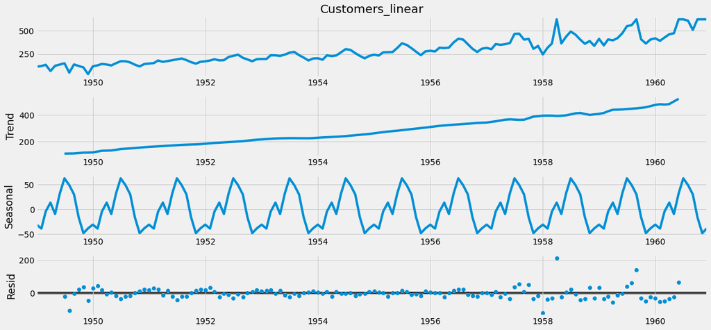

```python
import statsmodels.api as sm
plt.rcParams['figure.figsize'] = (17,8)

decomposition = sm.tsa.seasonal_decompose(data['Customers_linear'], model='additive')
decomposition.plot()

plt.show()
```

### Multiplicative Seasonal decomposition

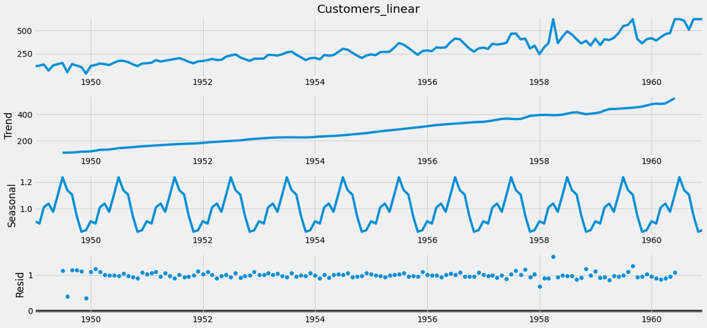

```python
plt.rcParams['figure.figsize'] = (17,8)

decomposition = sm.tsa.seasonal_decompose(data['Customers_linear'], model='multiplicative')
fig = decomposition.plot()
plt.show()
```

## Splitting train and test data

We Split the data into train and test. First 115 rows as the train data and rest other as test data

```python
print(data.shape)
length_train = 115
train = data.iloc[:length_train,:]
test=data.iloc[length_train:,: ]

# lets check the shape of train
print(train.shape,test.shape)
```

```
(144, 2)
(115, 2) (29, 2)
```

## Smoothing techniques (Basic for forcasting values)

The naive method is the simplest method of all forecasting methods. It looks at the last historical data and extrapolates it for all the future values without adjusting or attempting to establish causal factors.

```python
def plot_smoothing(title = '',data = '',label_value = ''):
    plt.rcParams['figure.figsize'] = (17,5)

    plt.plot(train['Customers_linear'], label = 'Train')
    plt.plot(test['Customers_linear'], label = 'Test')
    plt.plot(data, label = label_value)

    plt.legend()
    plt.title(title)
    plt.show()
```

### Naive Method

The naive method is the simplest method of all forecasting methods. It looks at the last historical data and extrapolates it for all the future values without adjusting or attempting to establish causal factors.

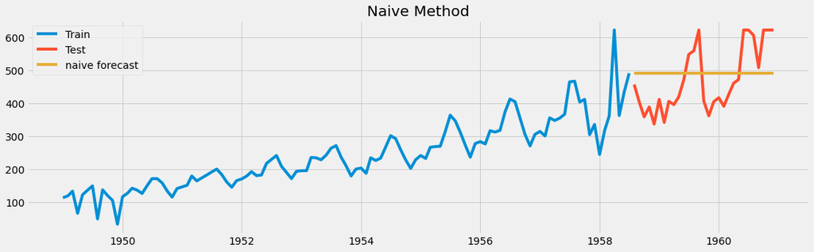

```
Mean Forecast Error of Naive Method : -19.0
```

```python
y_naive = test.copy()
y_naive['forecasted_naive'] = train['Customers_linear'][length_train-1]
plot_smoothing(title = 'Naive Method',data = y_naive['forecasted_naive'], label_value = 'naive forecast')

mean_forcast_error = np.round(np.mean(test['Customers_linear'] - y_naive['forecasted_naive']),2)
print(f'Mean Forecast Error of Naive Method : {mean_forcast_error}')
```

### Simple Average Method

In this method, we take the future predictions equal to the average of all the historical data.

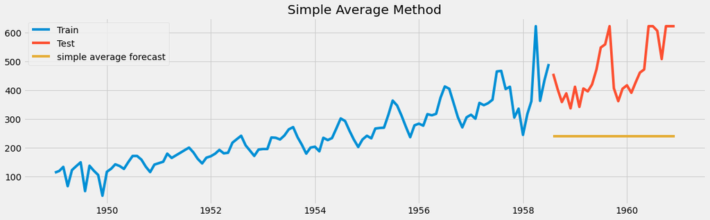

```
Mean Forecast Error of Simple Average Method : 232.05
Mean Absolute Error of Simple Average Method : 232.05
Mean Absolute Percentage Error of Simple Average Method : 47.06 %
RMSE of Simple Average Method : 251.75
```

```python
y_avg = test.copy()
y_avg['forecasted_avg'] = train['Customers_linear'].mean()
plot_smoothing(title = 'Simple Average Method',data = y_avg['forecasted_avg'], label_value = 'simple average forecast')

mean_forcast_error = np.round(np.mean(test['Customers_linear'] - y_avg['forecasted_avg']),2)
print(f'Mean Forecast Error of Simple Average Method : {mean_forcast_error}')

mean_absolute_error = np.round(np.mean(np.abs(test['Customers_linear'] - y_avg['forecasted_avg'])),2)
print(f'Mean Absolute Error of Simple Average Method : {mean_absolute_error}')

mean_absolute_percent_error = np.round(np.mean(np.abs(test['Customers_linear'] - y_avg['forecasted_avg'])/test['Customers_linear'])*100,2)
print(f'Mean Absolute Percentage Error of Simple Average Method : {mean_absolute_percent_error} %')

rmse = np.round(np.sqrt(mean_squared_error(test['Customers_linear'], y_avg['forecasted_avg'])),2)
print(f'RMSE of Simple Average Method : {rmse}')
```

### Simple Moving Average Method

In this method, we take the future predictions equal to the average of a moving window. A window can be a time period of 3 months, 6 months, 9 months or 1 year.

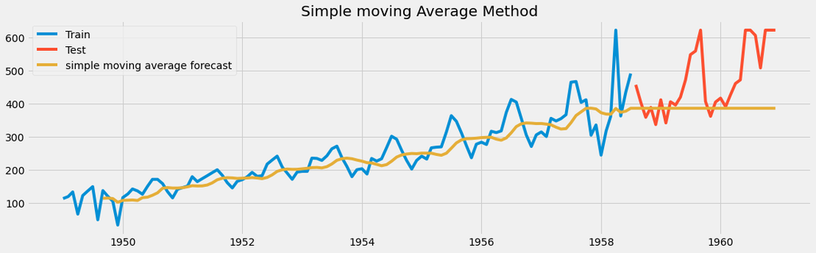

```python
y_moving = data.copy()

window = 9
y_moving["moving_average_forecast"] = data['Customers_linear'].rolling(window).mean()
y_moving['moving_average_forecast'][length_train:] = y_moving['moving_average_forecast'][length_train-1]
plot_smoothing(title = 'Simple moving Average Method',
               data = y_moving['moving_average_forecast'],
               label_value = 'simple moving average forecast')
```

### Simple Exponential Smoothing

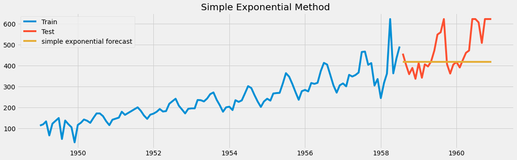

```python
from statsmodels.tsa.holtwinters import SimpleExpSmoothing

model = SimpleExpSmoothing(train['Customers_linear'])
model_fit = model.fit(smoothing_level=0.2)
model_fit.params
y_exp = test.copy()
y_exp['Exponential_forecast'] = model_fit.forecast(y_exp.shape[0])
plot_smoothing(title = 'Simple Exponential Method',
               data = y_exp['Exponential_forecast'],
               label_value = 'simple exponential forecast')
```

### Holt Exponential Smoothing

Holt’s exponential smoothing captures the level and trend of time series in the forecast.

The forecast equation is a function of both level and trend.

y(t+1) = l(t) +b(t)

Where l(t) is the level component and b(t) is the trend component.

The trend component is calculated as shown

b(t) = β(l(t) - l(t-1)) + (1-β)b(t-1)

Here beta is the smoothing parameter for trend.

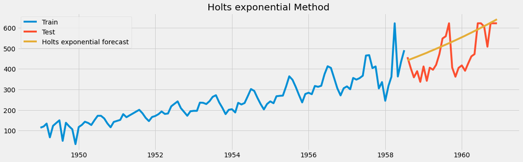

```python
from statsmodels.tsa.holtwinters import ExponentialSmoothing

model = ExponentialSmoothing(train['Customers_linear'], seasonal_periods=12, trend='multiplicative')
model_fit = model.fit(smoothing_level=0.2,smoothing_slope=0.04)
model_fit.params
y_holtexponential = test.copy()
y_holtexponential['holtexponential_forecast'] = model_fit.forecast(y_holtexponential.shape[0])

plot_smoothing(title = 'Holts exponential Method',
               data = y_holtexponential['holtexponential_forecast'],
               label_value = 'Holts exponential forecast')
```

### Holt Winter Exponential Smoothing

This techniques forecasts based on level, trend and seasonality. The forecast equation for this method includes seasonality.

y(t+1) = l(t)+b(t)+s(t+1-m) Here m is the number of time a season repeats in a time period.

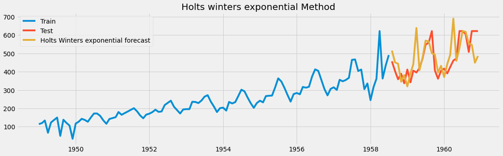

```
Mean Forecast Error of Holt Winter Exponential Smoothing Method : -11.9
Mean Absolute Error of Holt Winter Exponential Smoothing Method : 67.33
Mean Absolute Percentage Error of Holt Winter Exponential Smoothing Method : 14.66 %
RMSE of Holt Winter Exponential Smoothing Method : 90.83
```

```python
model = ExponentialSmoothing(train['Customers_linear'], seasonal_periods=12, trend='multiplicative', seasonal='additive')
model_fit = model.fit(smoothing_level=0.2,smoothing_slope=0.04)
model_fit.params
y_holtwinter = test.copy()
y_holtwinter['holtwinter_forecast'] = model_fit.forecast(y_holtwinter.shape[0])
plot_smoothing(title = 'Holts winters exponential Method',
               data = y_holtwinter['holtwinter_forecast'],
               label_value = 'Holts Winters exponential forecast')

mean_forcast_error = np.round(np.mean(test['Customers_linear'] - y_holtwinter['holtwinter_forecast']),2)
print(f'Mean Forecast Error of Holt Winter Exponential Smoothing Method : {mean_forcast_error}')


mean_absolute_error = np.round(np.mean(np.abs(test['Customers_linear'] - y_holtwinter['holtwinter_forecast'])),2)
print(f'Mean Absolute Error of Holt Winter Exponential Smoothing Method : {mean_absolute_error}')

mean_absolute_percent_error = np.round(np.mean(np.abs(test['Customers_linear'] - y_holtwinter['holtwinter_forecast'])/test['Customers_linear'])*100,2)
print(f'Mean Absolute Percentage Error of Holt Winter Exponential Smoothing Method : {mean_absolute_percent_error} %')

rmse = np.round(np.sqrt(mean_squared_error(test['Customers_linear'], y_holtwinter['holtwinter_forecast'])),2)
print(f'RMSE of Holt Winter Exponential Smoothing Method : {rmse}')
```

## Stationarity

Stationarity means that the statistical properties of a process generating a time series do not change over time. The statistical properties are Mean, variance and covariance which are same irrespective of the time at which you observe them.

Stationarity is an important concept as stationary processes are easier to analyze and model because their statistical properties do not change over time.

### Augmented Dickey-Fuller Test for Stationarity

Augmented Dickey Fuller test (ADF Test) is a common statistical test used to test whether a given Time series is stationary or not. It is one of the most commonly used statistical test when it comes to analyzing the stationary of a series.

- p-value > 0.05: Fail to reject the null hypothesis (H0), the data has a unit root and is non-stationary.
- p-value <= 0.05: Reject the null hypothesis (H0), the data does not have a unit root and is stationary.

```python
from statsmodels.tsa.stattools import adfuller

result = adfuller(data['Customers_linear'], autolag='AIC')
print(f'ADF Statistic: {result[0]}')
print(f'n_lags: {result[2]}')
print(f'p-value: {result[1]}')
for key, value in result[4].items():
    print('Critial Values:')
    print(f'   {key}, {value}')
```

```
ADF Statistic: 2.7105600112832833
n_lags: 14
p-value: 0.9990875034273379
Critial Values:
   1%, -3.482087964046026
Critial Values:
   5%, -2.8842185101614626
Critial Values:
   10%, -2.578864381347275
```

- p-value is 1 and its value is larger than 0.05 , hence it fails to reject the null hypothesis. Hence, the data has a unit root and is non-stationary
- The mean value is not stationary.
- The variance is fluctating over time.

### Kwiatkowski-Phillips-Schmidt-Shin (KPSS) Test

The Kwiatkowski–Phillips–Schmidt–Shin (KPSS) test figures out if a time series is stationary around a mean or linear trend, or is non-stationary due to a unit root. A stationary time series is one where statistical properties — like the mean and variance — are constant over time.

For KPSS test,

The Null Hypothesis : The series is stationary when p-value >0.05

Alternate Hypothesis: The series is not stationary when p-value <= 0.5

```python
#loading kpss from statsmodel
from statsmodels.tsa.stattools import kpss

result = kpss(data['Customers_linear'])
print(f'KPSS Statistic: {result[0]}')
print(f'p-value: {result[1]}')
print(f'num lags: {result[2]}')
print('Critial Values:')
for key, value in result[3].items():
    print('Critial Values:')
    print(f'   {key}, {value}')
```

```
KPSS Statistic: 1.0654466813105485
p-value: 0.01
num lags: 14
Critial Values:
Critial Values:
   10%, 0.347
Critial Values:
   5%, 0.463
Critial Values:
   2.5%, 0.574
Critial Values:
   1%, 0.739
```

## Non-Stationary Series to Stationary Series

There are two tools for converting a non-stationary series into a stationary series.

1) Differencing

2) Transformation

Differencing tool is used to make the mean constant for a time series. That means it removes the trend from the series.

Differencing means to calculate the difference between consecutive observations. Differencing stabilises the mean of the time series by removing the trend from the series.

The procedure is to find the optimal value of lambda between -5 and +5 to minimize the variance of the time series.

### Box Cox Transformation

A Box Cox transformation is a way to transform non-normal dependent variables into a normal shape. Normality is an important assumption for many statistical techniques; if your data isn't normal, applying a Box-Cox means that you are able to run a broader number of tests.

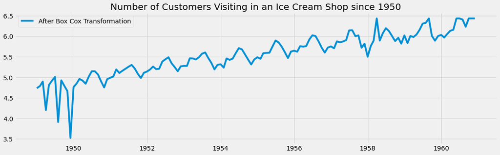

```python
from scipy.stats import boxcox

data_boxcox = pd.Series(boxcox(data['Customers_linear'],lmbda=0),index=data.index)
plt.plot(data_boxcox, label="After Box Cox Transformation")
plt.legend()
plt.title("Number of Customers Visiting in an Ice Cream Shop since 1950")
plt.show()
```

### Differencing

Differencing stabilises the mean of a time series by removing changes in the level of a time series, and therefore eliminating (or reducing) trend and seasonality.

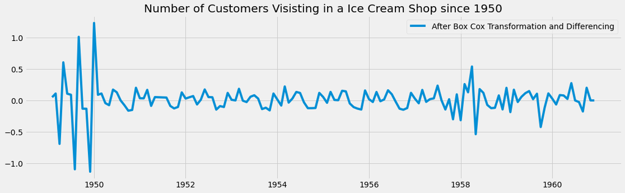

```python
data_boxcox_difference= pd.Series(data_boxcox - data_boxcox.shift(), index=data.index)
data_boxcox_difference.dropna(inplace=True)
plt.plot(data_boxcox_difference, label="After Box Cox Transformation and Differencing")
plt.legend()
plt.title("Number of Customers Visisting in a Ice Cream Shop since 1950")
plt.show()
```

### Let's check

```python
from statsmodels.tsa.stattools import adfuller

result = adfuller(data_boxcox_difference, autolag='AIC')
print(f'ADF Statistic: {result[0]}')
print(f'n_lags: {result[1]:.20f}')
print(f'p-value: {result[1]:.20f}')
for key, value in result[4].items():
    print('Critial Values:')
    print(f'   {key}, {value}')
```

```
ADF Statistic: -11.770270241136199
n_lags: 0.00000000000000000000
p-value: 0.00000000000000000000
Critial Values:
   1%, -3.4808880719210005
Critial Values:
   5%, -2.8836966192225284
Critial Values:
   10%, -2.5785857598714417
```

```python
from statsmodels.tsa.stattools import kpss
result = kpss(data_boxcox_difference)
print(f'KPSS Statistic: {result[0]}')
print(f'p-value: {result[1]}')
print(f'num lags: {result[2]}')
print('Critial Values:')
for key, value in result[3].items():
    print('Critial Values:')
    print(f'   {key}, {value}')
```

```
KPSS Statistic: 0.05598972890922356
p-value: 0.1
num lags: 14
Critial Values:
Critial Values:
   10%, 0.347
Critial Values:
   5%, 0.463
Critial Values:
   2.5%, 0.574
Critial Values:
   1%, 0.739
```

## Auto Correleation Function (ACF)

ACF is an (complete) auto-correlation function which gives us values of auto-correlation of any series with its lagged values.

The blue color area is a specified band, as the correlation above the band would be consider as the significant correlation value

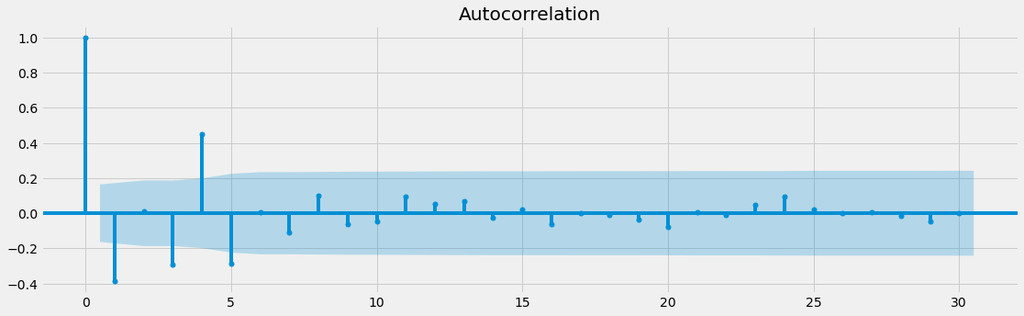

```python
#Loading and plotting acf
from statsmodels.graphics.tsaplots import plot_acf

plot_acf(data_boxcox_difference, ax=plt.gca(), lags=30)
plt.show()
```

## Partial Auto Correleation Function (PACF)

Partial autocorrelation function (PACF) gives the partial correlation of a stationary time series with its own lagged values, regressed the values of the time series at all shorter lags. It contrasts with the autocorrelation function, which does not control for other lags.

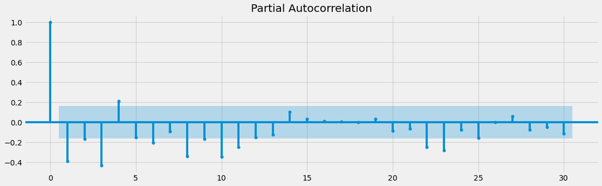

```python
#Loading and plottin pacf
from statsmodels.graphics.tsaplots import plot_pacf
plot_pacf(data_boxcox_difference, ax=plt.gca(), lags=30)
plt.show()
```

## Splitting Data for Modeling

```python
length_train = 115

train = data.iloc[:length_train,:]
test = data.iloc[length_train:,:]

train_data_boxcox = data_boxcox[:length_train]
test_data_boxcox = data_boxcox[length_train:]

# here is -1 because during differencing we remove the top row
train_data_boxcox_difference = data_boxcox_difference[:length_train-1]
test_data_boxcox_difference = data_boxcox_difference[length_train-1:]
```

## Auto Regressive Model

- Regressive model is forecasting the future observations as a linear regression of one or more past observations.
- This model has a parameter called “p” which is the lag order p that means p is the maximum number of lags that we consider in order to forecast the future observations.
- Autoregressive model equation would be

y(t) = β_0 + β_1 y(t-2) + β_2 y(t-4) + β_3 y(t-6)

```
const      0.012440
ar.L1.y   -0.398536
dtype: float64
```

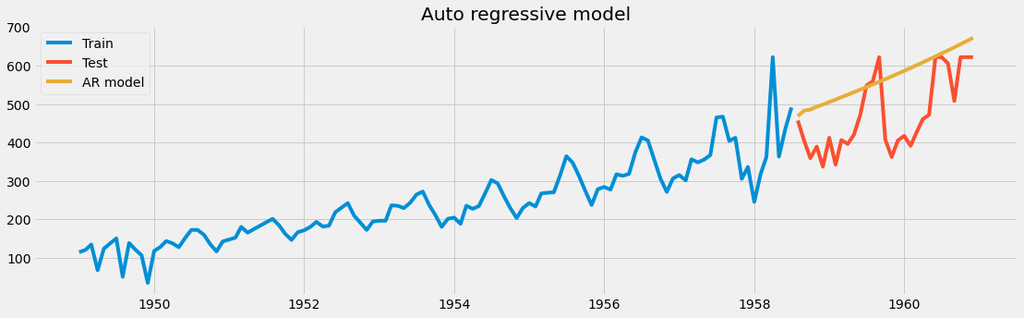

```python
from statsmodels.tsa.arima_model import ARIMA

model_ar = ARIMA(train_data_boxcox_difference, order=(1,0,0))
model_fit = model_ar.fit()
print(model_fit.params)

### Recover Original Series
y_ar_new = data_boxcox_difference.copy()
y_ar_new['ar_forecast_boxcox_difference'] = model_fit.predict(data_boxcox_difference.index.min(),
                                                              data_boxcox_difference.index.max())   #+ timedelta(days=1000))


# y_ar_new['ar_forecast_boxcox_difference'] = model_fit.predict(0,train_data_boxcox_difference.shape[0]+test_data_boxcox_difference.shape[0])

y_ar_new['ar_forecast_boxcox'] = y_ar_new['ar_forecast_boxcox_difference'].cumsum()
y_ar_new['ar_forecast_boxcox'] = y_ar_new['ar_forecast_boxcox'].add(data_boxcox[0])
y_ar_new['ar_forecast'] = np.exp(y_ar_new['ar_forecast_boxcox'])

plot_smoothing(title = 'Auto regressive model',
               data = y_ar_new['ar_forecast'][test.index.min():],
               label_value = 'AR model')
```

## Moving Average Model

In Moving Average Model, we consider the past forecasted errors to forecast the future values.

The moving average model has a parameter called “q” which is the size of the moving average window over which linear combinations of errors are calculated.

The mathematical equation is:-

y(t) = µ + φ(k)*ε(t-k)

µ is the mean of the series

ε(t-k) is the past forecasted value

φ(k) is the weight associated with error value

```
const      0.012553
ma.L1.y   -0.539880
ma.L2.y   -0.200034
ma.L3.y   -0.146816
ma.L4.y    0.627897
ma.L5.y   -0.310058
ma.L6.y   -0.113329
ma.L7.y   -0.317780
dtype: float64
```

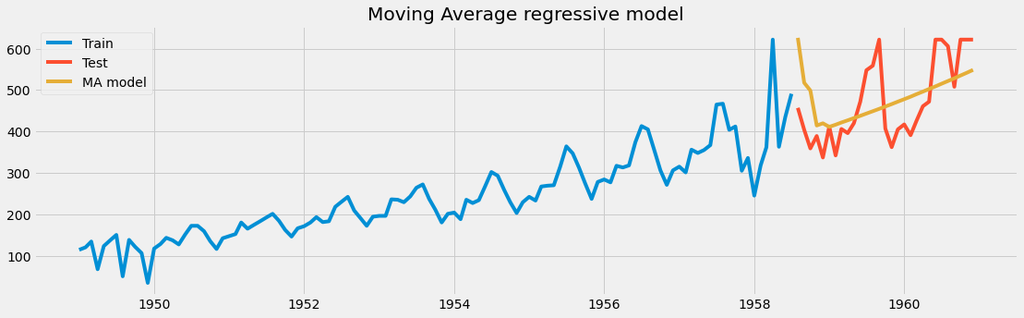

```python
#from statsmodels.tsa.arima_model import ARIMA
model_ma = ARIMA(train_data_boxcox_difference, order=(0,0,7))
model_fit = model_ma.fit()
print(model_fit.params)

# recover original time series
y_ma_new = data_boxcox_difference.copy()
y_ma_new['ma_forecast_boxcox_difference'] = model_fit.predict(data_boxcox_difference.index.min(), data_boxcox_difference.index.max())
y_ma_new['ma_forecast_boxcox'] = y_ma_new['ma_forecast_boxcox_difference'].cumsum()
y_ma_new['ma_forecast_boxcox'] = y_ma_new['ma_forecast_boxcox'].add(data_boxcox[0])
y_ma_new['ma_forecast'] = np.exp(y_ma_new['ma_forecast_boxcox'])

plot_smoothing(title = 'Moving Average regressive model',
               data = y_ma_new['ma_forecast'][test.index.min():],
               label_value = 'MA model')
```

## Auto Regressive Moving Average Model (ARMA)

ARMA Model combines both AR and MA model.

It takes into account one or more past observations as well as the past errors.

The ARMA model contains two parameters p and q

p is the highest lag in the time series

q is the number of past errors included

```
const      0.012104
ar.L1.y   -0.734504
ma.L1.y    0.172158
ma.L2.y   -0.738009
ma.L3.y   -0.609403
ma.L4.y    0.175254
dtype: float64
```

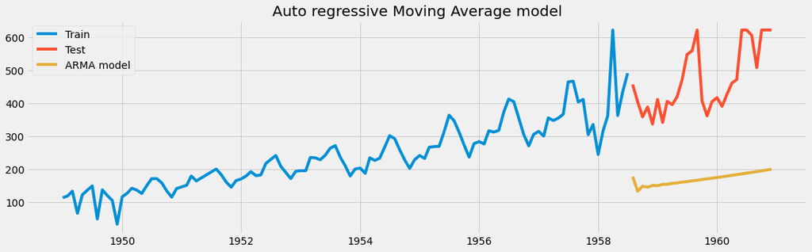

```python
from statsmodels.tsa.arima_model import ARIMA

model_arma = ARIMA(train_data_boxcox_difference, order=(1,0,4))
model_fit = model_arma.fit()
print(model_fit.params)

# recover original time series
y_arma_new = data_boxcox_difference.copy()
y_arma_new['arma_forecast_boxcox_difference'] = model_fit.predict(data_boxcox_difference.index.min(),
                                                                  data_boxcox_difference.index.max())
y_arma_new['arma_forecast_boxcox'] = y_arma_new['arma_forecast_boxcox_difference'].cumsum()
y_arma_new['arma_forecast_boxcox'] = y_arma_new['arma_forecast_boxcox'].add(data_boxcox[0])
y_arma_new['arma_forecast'] = np.exp(y_arma_new['arma_forecast_boxcox'])

plot_smoothing(title = 'Auto regressive Moving Average model',
               data = y_arma_new['arma_forecast'][test.index.min():],
               label_value = 'ARMA model')
```

> ARMA model works very poor on this dataset

## Auto Regressive Integrated Moving Average Model (ARIMA)

It transform the time series using Box Cox and then itself takes care of the differencing and remove the trend from the time series.

We have three parameters to be used:-

p is the highest lag in the model

d is the degree of differencing to make the series stationary

q is the number of past errors terms included

```
const        0.012133
ar.L1.D.y   -0.565942
ar.L2.D.y   -0.053259
ar.L3.D.y    0.345502
ma.L1.D.y   -0.061830
ma.L2.D.y   -0.561643
ma.L3.D.y   -0.825870
ma.L4.D.y    0.449347
dtype: float64
```

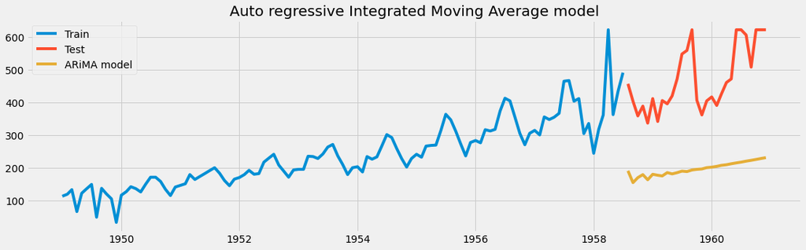

```
Mean Forecast Error of ARIMA : 274.66
Mean Absolute Error of ARIMA : 274.66
Mean Absolute Percentage Error of ARIMA : 57.06 %
RMSE of ARIMA : 287.49
```

```python
from statsmodels.tsa.arima_model import ARIMA

model = ARIMA(train_data_boxcox, order=(3,1,4))
model_fit = model.fit()
print(model_fit.params)

y_arima_new = data_boxcox_difference.copy()
y_arima_new['arima_forecast_boxcox_difference'] = model_fit.predict(data_boxcox_difference.index.min(),
                                                                    data_boxcox_difference.index.max())
y_arima_new['arima_forecast_boxcox'] = y_arima_new['arima_forecast_boxcox_difference'].cumsum()
y_arima_new['arima_forecast_boxcox'] = y_arima_new['arima_forecast_boxcox'].add(data_boxcox[0])
y_arima_new['arima_forecast'] = np.exp(y_arima_new['arima_forecast_boxcox'])

plot_smoothing(title = 'Auto regressive Integrated Moving Average model',
               data = y_arima_new['arima_forecast'][test.index.min():],
               label_value = 'ARiMA model')

mean_forcast_error = np.round(np.mean(test['Customers_linear'] - y_arima_new['arima_forecast'][test.index.min():]),2)
print(f'Mean Forecast Error of ARIMA : {mean_forcast_error}')

mean_absolute_error = np.round(np.mean(np.abs(test['Customers_linear'] -  y_arima_new['arima_forecast'][test.index.min():])),2)
print(f'Mean Absolute Error of ARIMA : {mean_absolute_error}')

mean_absolute_percent_error = np.round(np.mean(np.abs(test['Customers_linear'] - y_arima_new['arima_forecast'][test.index.min():])/test['Customers_linear'])*100,2)
print(f'Mean Absolute Percentage Error of ARIMA : {mean_absolute_percent_error} %')

rmse = np.round(np.sqrt(mean_squared_error(test['Customers_linear'], y_arima_new['arima_forecast'][test.index.min():])),2)
print(f'RMSE of ARIMA : {rmse}')
```

## Seasonal Auto Regressive Integrated Moving Average Model (SARIMA)

SARIMA model brings all the features of ARIMA model along with the seasonality.

```
ar.L1     -0.576912
ma.L1     -0.998549
ar.S.L6   -0.733960
ma.S.L6   -0.539606
sigma2     0.049815
dtype: float64
```

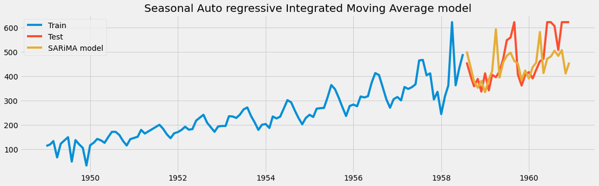

```python
from statsmodels.tsa.statespace.sarimax import SARIMAX

model = SARIMAX(train_data_boxcox_difference, order=(1,1,1), seasonal_order=(1,1,1,6))
model_fit = model.fit()
print(model_fit.params)

y_sarima_new = data_boxcox_difference.copy()
y_sarima_new['sarima_forecast_boxcox_difference'] = model_fit.predict(data_boxcox_difference.index.min(),
                                                                      data_boxcox_difference.index.max())
y_sarima_new['sarima_forecast_boxcox'] = y_sarima_new['sarima_forecast_boxcox_difference'].cumsum()
y_sarima_new['sarima_forecast_boxcox'] = y_sarima_new['sarima_forecast_boxcox'].add(data_boxcox[0])
y_sarima_new['sarima_forecast'] = np.exp(y_sarima_new['sarima_forecast_boxcox'])

plot_smoothing(title = 'Seasonal Auto regressive Integrated Moving Average model',
               data = y_sarima_new['sarima_forecast'][test.index.min():],
               label_value = 'SARiMA model')
```